# White Wine Exploration by Divya Ramanujachari

This report analyses the results of physicochemical tests on 4898 samples of white wine with a view toward determining the factors that impact the wine quality.

# Univariate Plots Section

### Dimensions of the dataset

```
## [1] 4898   13
```

### Fields in the dataset

```
## 'data.frame':    4898 obs. of  13 variables:
##  $ X                   : int  1 2 3 4 5 6 7 8 9 10 ...
##  $ fixed.acidity       : num  7 6.3 8.1 7.2 7.2 8.1 6.2 7 6.3 8.1 ...
##  $ volatile.acidity    : num  0.27 0.3 0.28 0.23 0.23 0.28 0.32 0.27 0.3 0.22 ...
##  $ citric.acid         : num  0.36 0.34 0.4 0.32 0.32 0.4 0.16 0.36 0.34 0.43 ...
##  $ residual.sugar      : num  20.7 1.6 6.9 8.5 8.5 6.9 7 20.7 1.6 1.5 ...
##  $ chlorides           : num  0.045 0.049 0.05 0.058 0.058 0.05 0.045 0.045 0.049 0.044 ...
##  $ free.sulfur.dioxide : num  45 14 30 47 47 30 30 45 14 28 ...
##  $ total.sulfur.dioxide: num  170 132 97 186 186 97 136 170 132 129 ...
##  $ density             : num  1.001 0.994 0.995 0.996 0.996 ...
##  $ pH                  : num  3 3.3 3.26 3.19 3.19 3.26 3.18 3 3.3 3.22 ...
##  $ sulphates           : num  0.45 0.49 0.44 0.4 0.4 0.44 0.47 0.45 0.49 0.45 ...
##  $ alcohol             : num  8.8 9.5 10.1 9.9 9.9 10.1 9.6 8.8 9.5 11 ...
##  $ quality             : int  6 6 6 6 6 6 6 6 6 6 ...
```

### Preprocessing

The last category is directly related to the statement from the description that says “density depends on the percent alcohol and sugar content.”

### Factors related to acidity

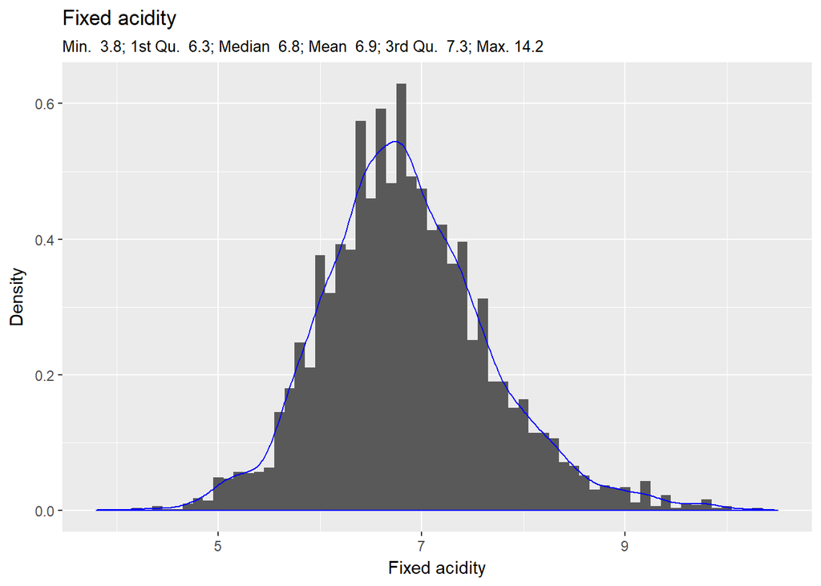

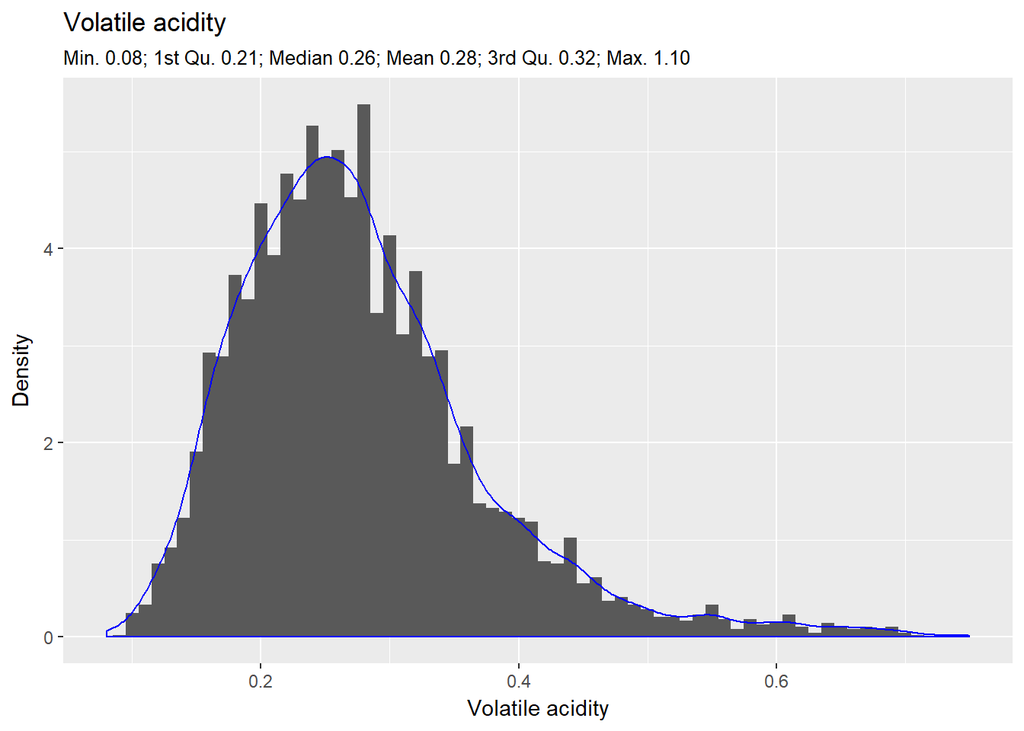

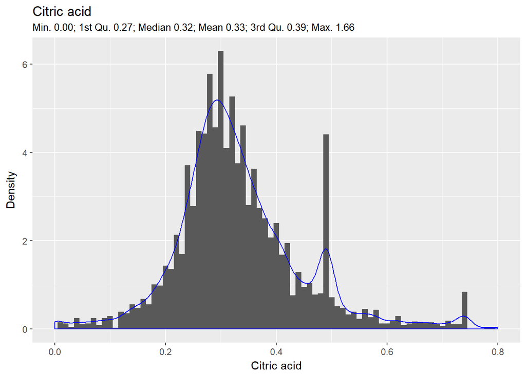

The fixed acidity appears to be distributed normally around the median of 6.8. Outliers are present, as shown by the gap between the third quantile and maximum value. The volatile acidity is positively skewed with a long tail. The reason for this might be that, according to the description, high levels of volatile acids affect the wine taste. The citric acid values are mostly normal, with an intriguing peak near 0.5.

### Factors related to sulfur dioxide

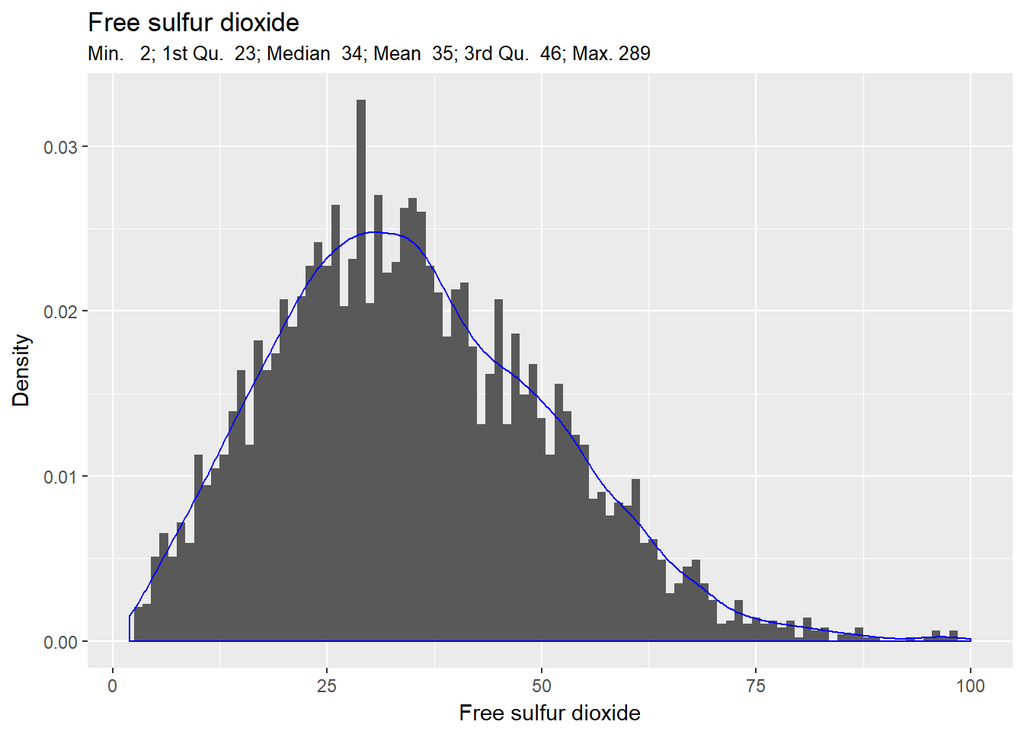

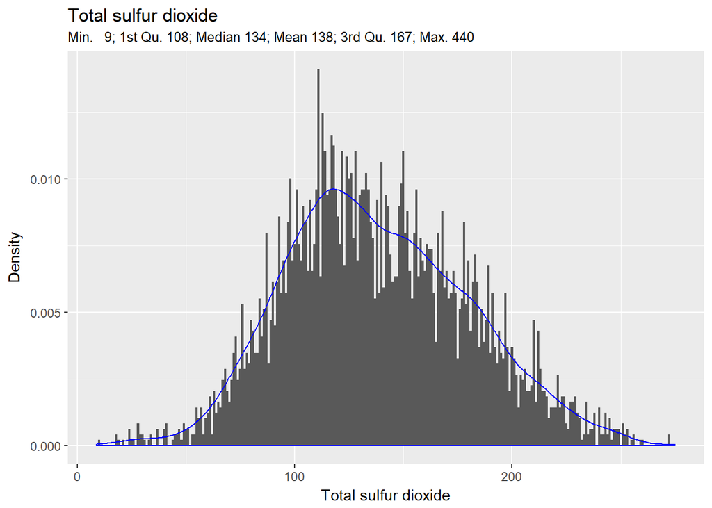

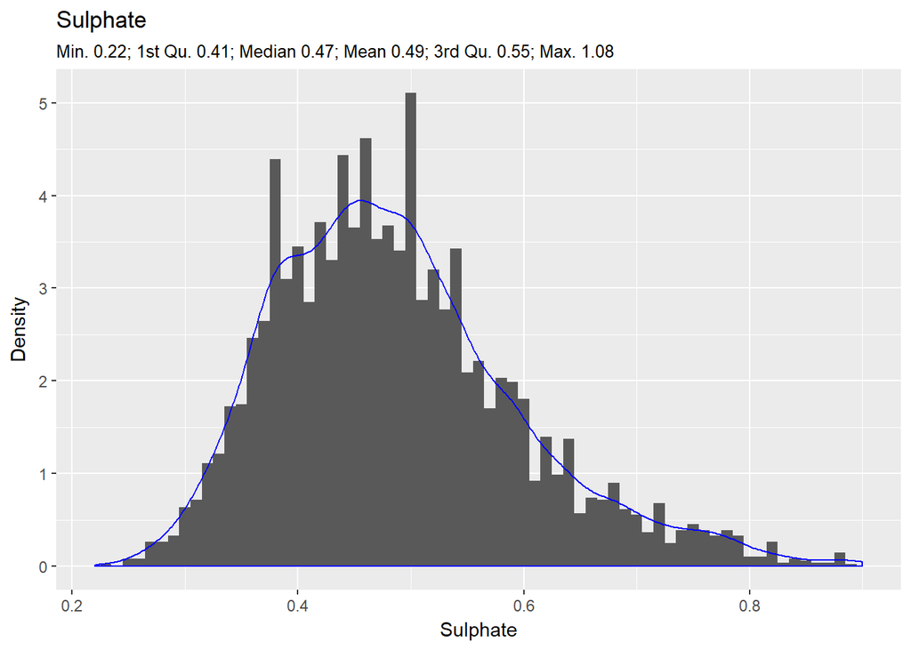

The free sulfur dioxide distribution appears to be long-tailed; please note that outliers, not shown in the plot, exist sporadically till a max of 289. According to the variable description document this is used as a preservative. The total sulfur dioxide also shows some high values; this is said to affect the quality of wines and must be investigated further. Described as an antimicrobial and antioxidant, sulphates are somewhat normally distributed but values in the higher range are also observed.

### Factors related to salinity

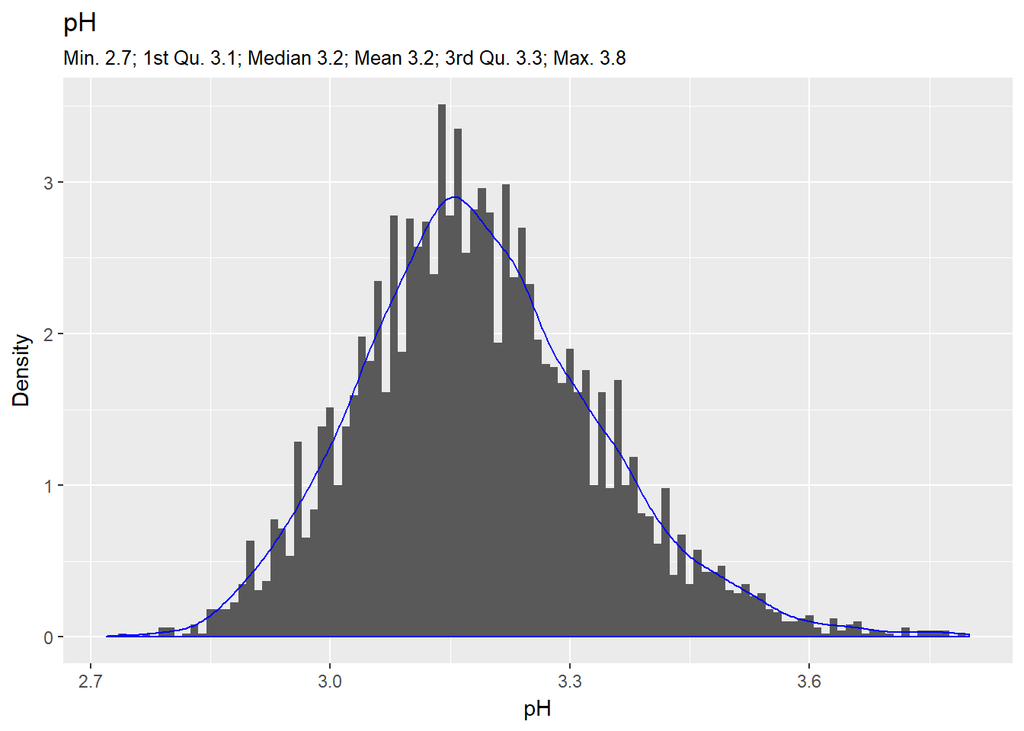

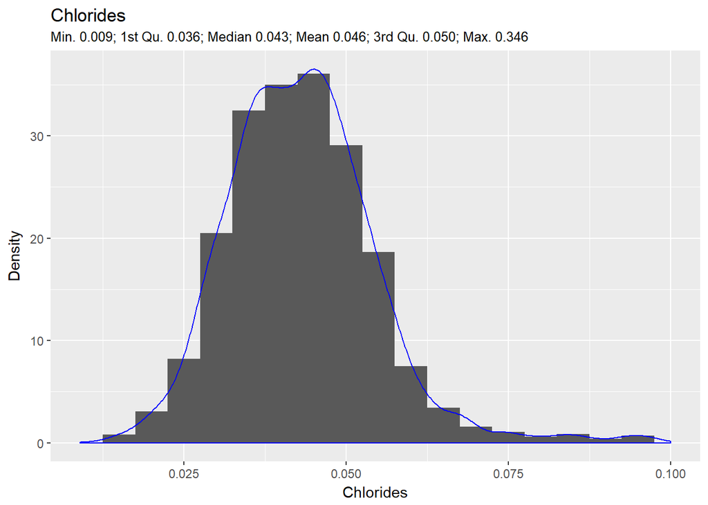

### Factors related to density

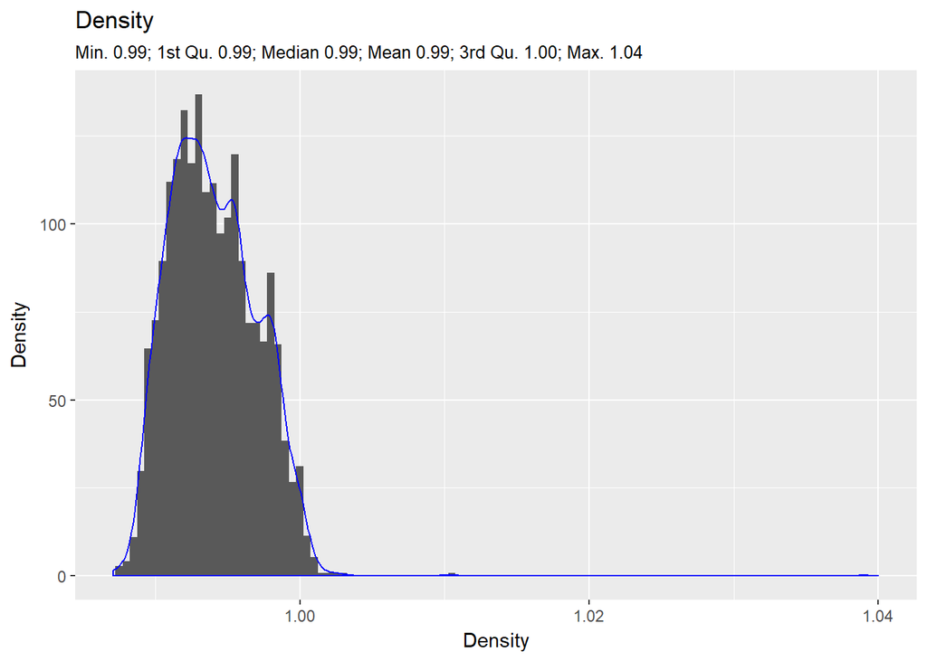

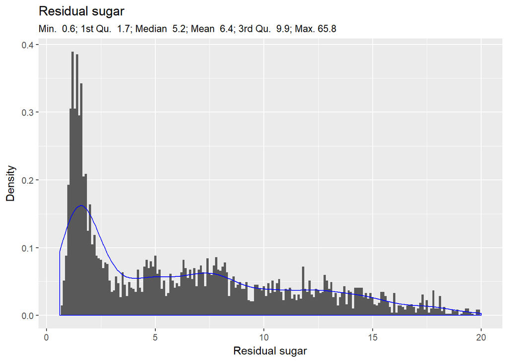

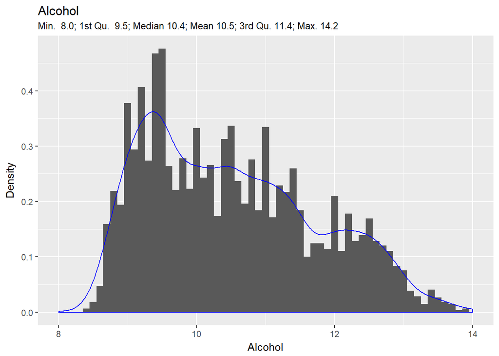

The density values do not show much variability, a couple of outliers are observed very far from the mean. The residual sugar is positively skewed and has a very long tail. The values cover a large range from 0.6 to 65.8. This is also the trend of the alcohol value distribution. There is a spike at 9.5, which is below the median and mean values.

### Quality attribute

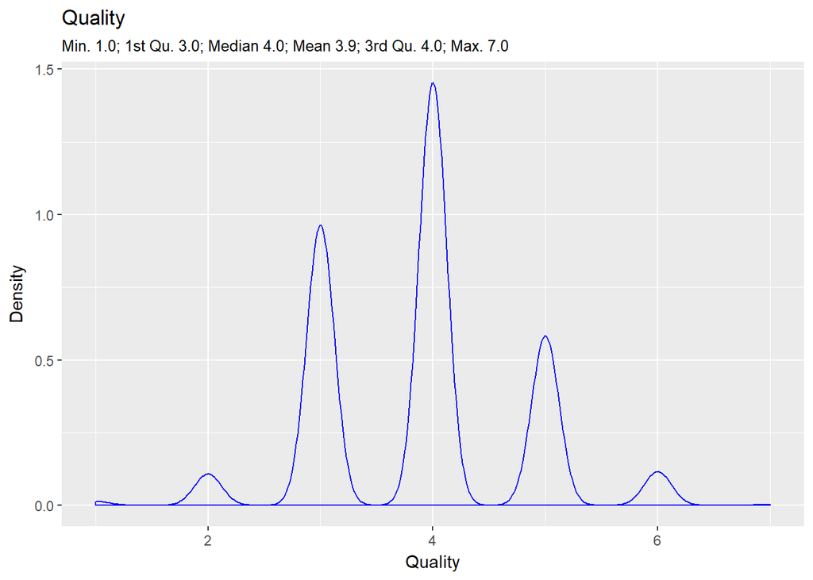

This graph indicates how the dataset is not well balanced in terms of wine quality; there are many wines in the mediocre range but very few that can be labelled as very bad or very good.

# Univariate Analysis

### What is the structure of your dataset?

The dataset comprises 4898 observations with 13 variables, of which 11 are physicochemical properties and one (quality) quantifies a sensory parameter. The remaining one is an identifier. A detailed description of the attributes was provided with the dataset.

### What is/are the main feature(s) of interest in your dataset?

As mentioned, the objective of the study is to determine the factors that influence quality and this is the main feature of interest. However, the provided dataset is not well balanced as most of the wines are of mediocre quality (rating of 5 to 7) and there are only a few examples of very bad or excellent wines. This might provide an incomplete picture.

### What other features in the dataset do you think will help support your investigation into your feature(s) of interest?

While answering this would require bivariate analysis with regard to quality, from the description, factors like volatile acidity, citric acid, total sulfur dioxide, and residual sugar have a direct effect on the taste. I will be investigating these in detail next.

### Did you create any new variables from existing variables in the dataset?

I did not create any new variable.

### Of the features you investigated, were there any unusual distributions?

In the citric acid value distribution there is an intriguing peak near 0.5, for which I could not find any reasonable explanation. Similarly there is a peak in the alcohol distribution at a value much below the mean/median, which is not in focus because of its very long tail.

### Did you perform any operations on the data to tidy, adjust, or change the form of the data? If so, why did you do this?

I dropped the variable X, which was only an identifier variable and not relevant to the investigation. I also cast the quality into a factor variable. Initially it was an integer variable, which was inconsistent with its description as a categorical variable that can take only specific values.

# Bivariate Plots Section

In this section, I first analysed the correlation between the various variables and the quality factor. Following this, the correlations between the variables were analyzed, for which I considered an absolute value of more than 0.5 as being noteworthy.

### Factors related to acidity

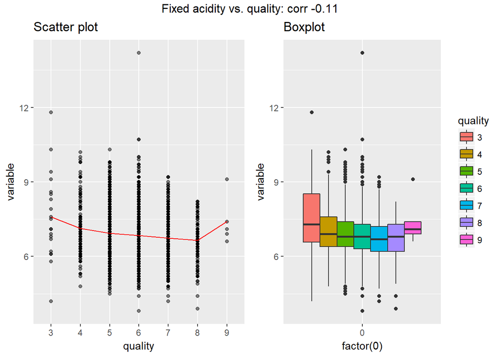

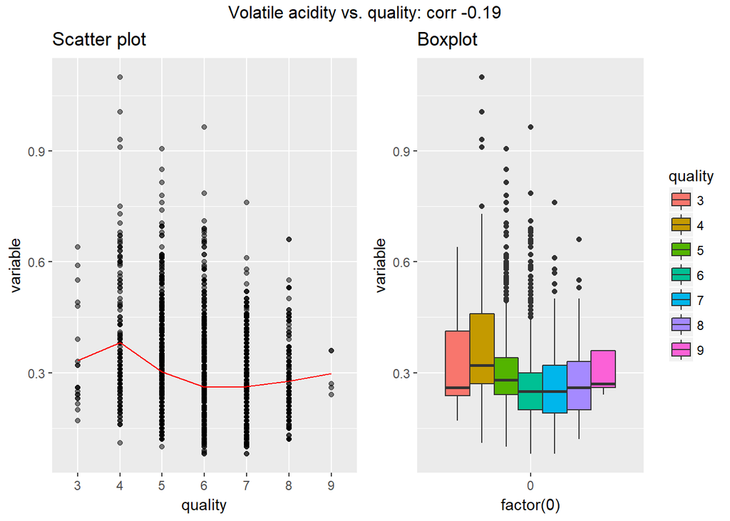

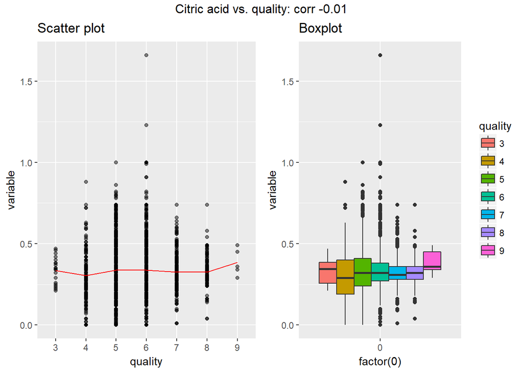

The correlation of fixed acidity, volatile acidity, and citric acid with quality was computed to be -0.11, -0.19, and -0.01. Looking at the scatterplot and boxplots I was not able to discern any strong pattern across the quality values.

### Factors related to sulfur dioxide

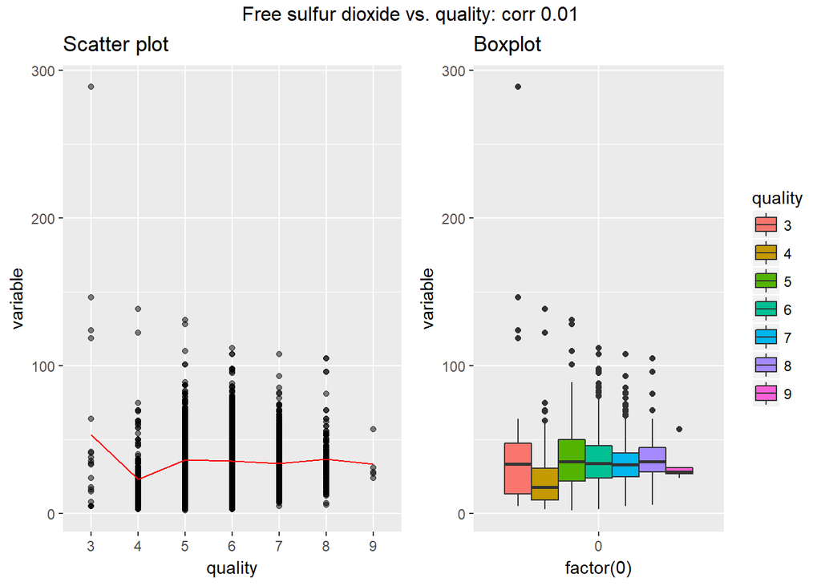

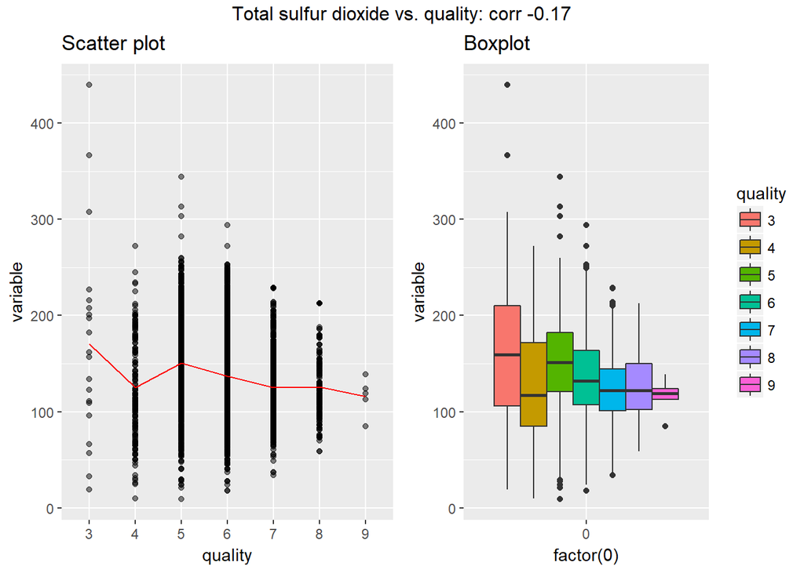

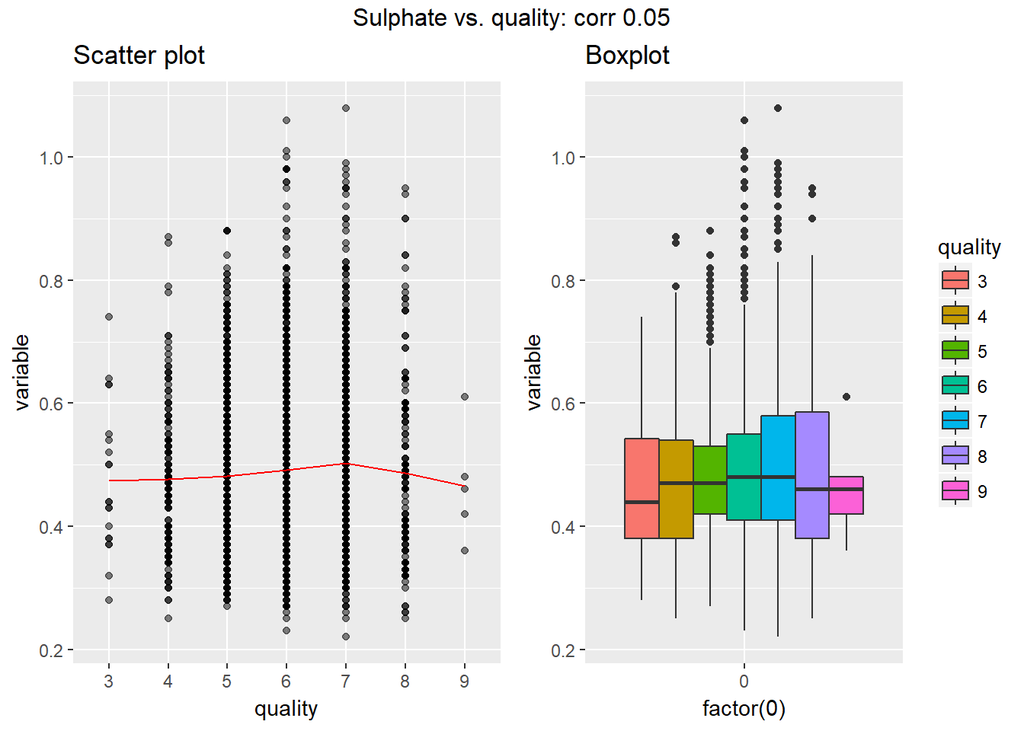

The correlation of free sulfur dioxide, total sulfur dioxide, and sulphates with quality was computed to be 0.01, -0.17, and 0.05. As in the previous set, I was not able to come to any conclusion about variation in quality from the plots.

### Factors related to salinity

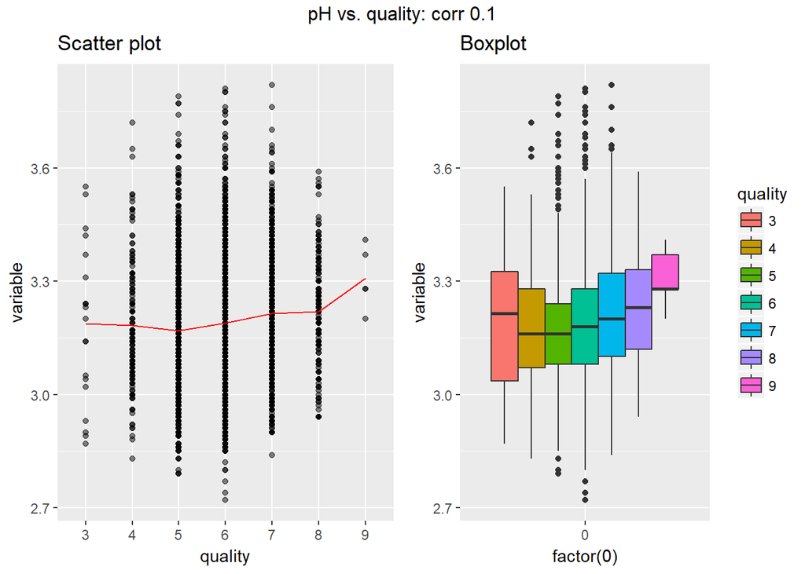

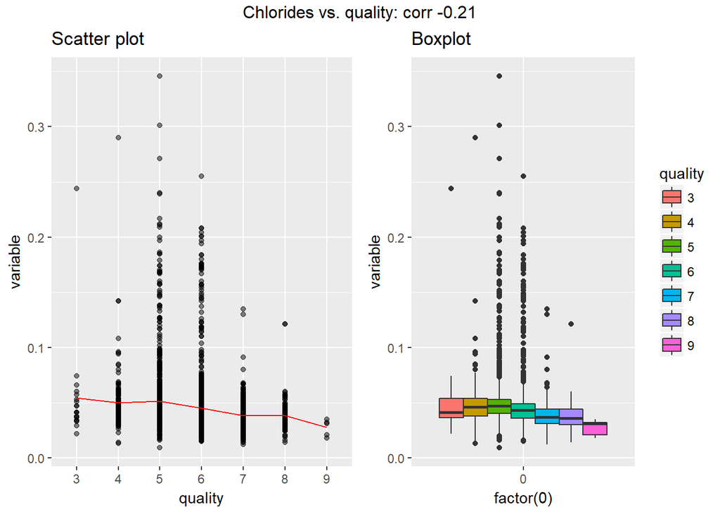

The correlation of pH and chlorides with quality was computed to be 0.1 and -0.21. From the plots, it was observed that higher quality wines tend to have higher pH on an average. Similarly higher quality wines tended to have lower chlorides on an average. However, these observations exclude the outliers and there are not enough samples in the bad and excellent categories for this observation to be significant.

### Factors related to density

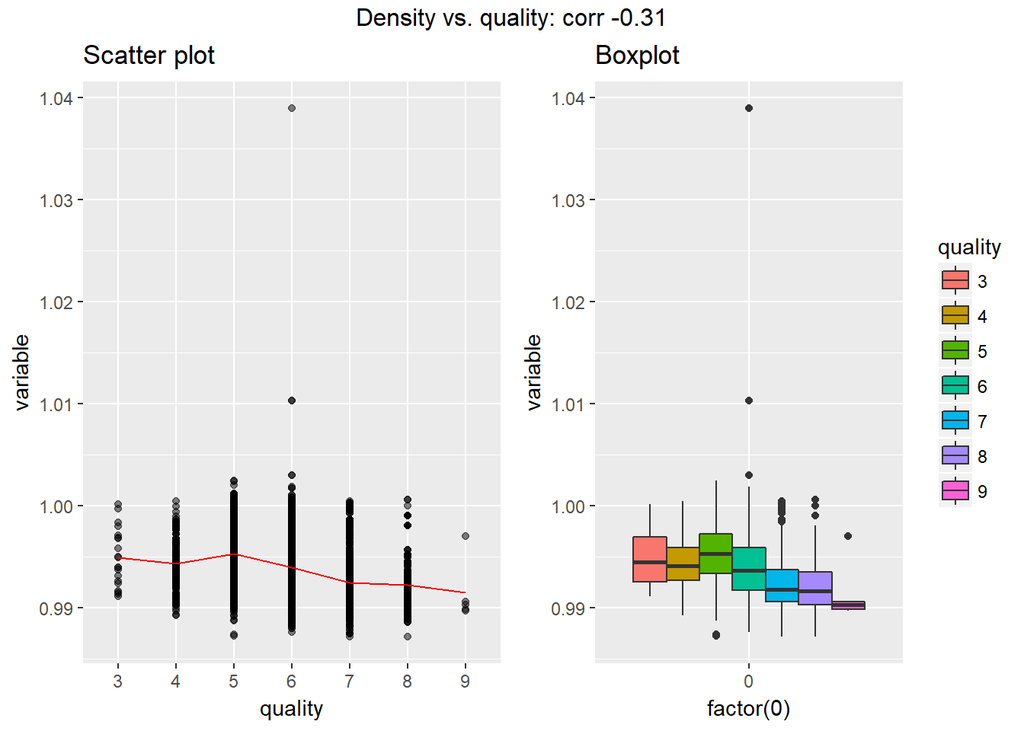

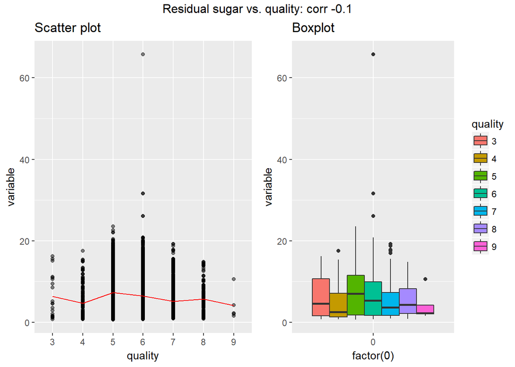

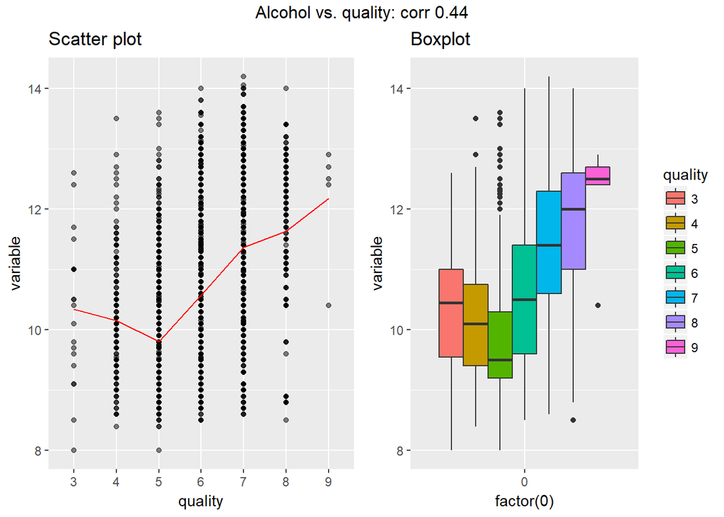

The correlation of density, residual sugar, and alcohol with quality was computed to be -0.31, -0.1, and 0.44. No clear trend was observed in the plots for residual sugars. An inverse trend was observed in the relation between the density and quality. Further, the alcohol level and quality appear to be positively correlated; in general, wines of better quality have higher levels of alcohol.

### Correlations between variables other than quality

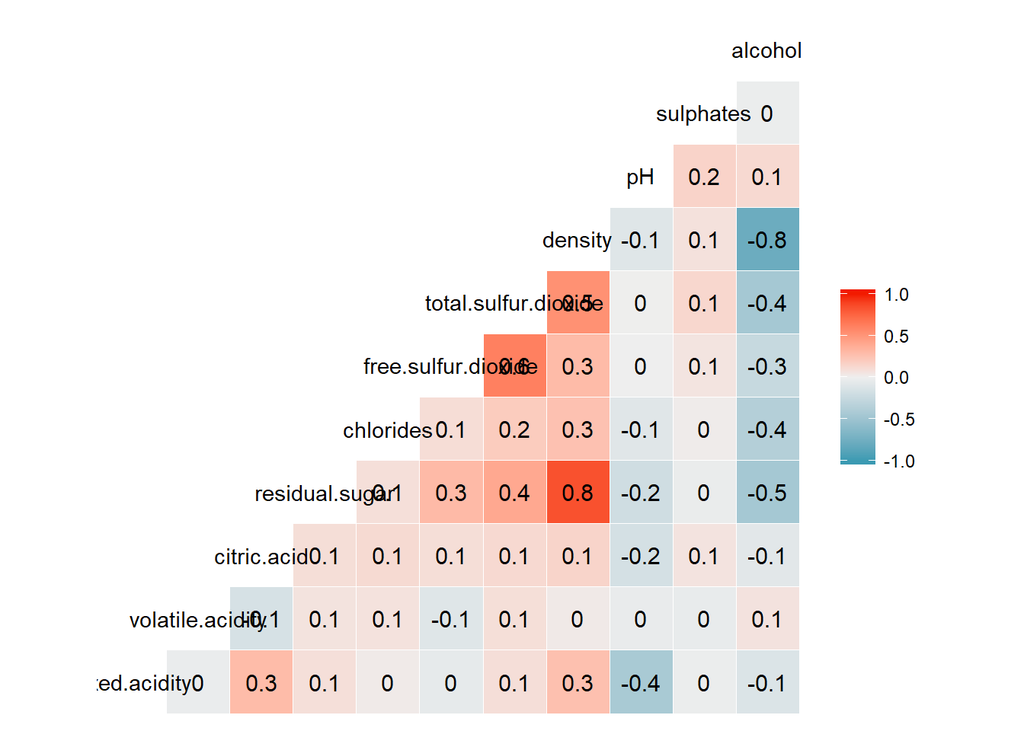

The matrix shows that the correlation between alcohol and density and residual sugar and density was found to be highest at 0.8. This was followed by the correlation between free sulfur dioxide and total sulfur dioxide, which was 0.6. Next, scatter plots are plotted to examine the linear relationship between the various variables and fit and approximate regression line.

### Plot of density vs. alcohol

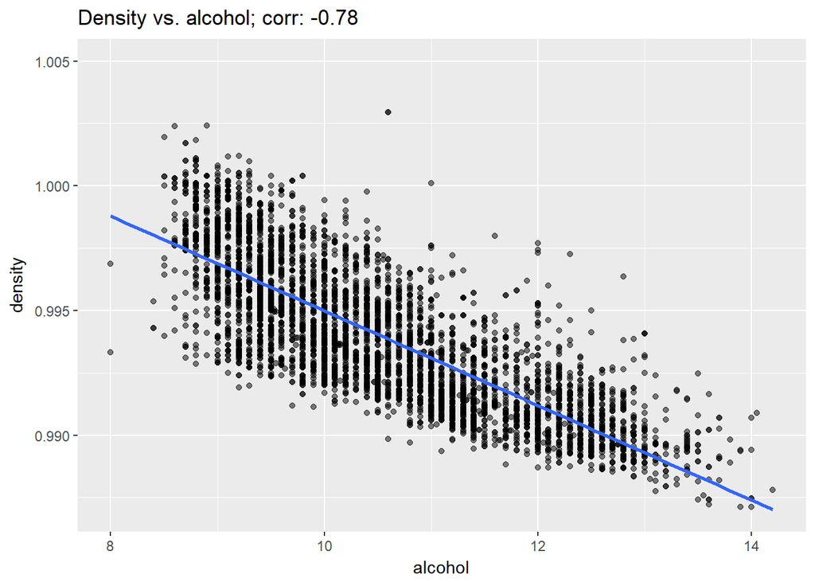

The correlation value is reflected by the good fit of the regression line; the relationship between density and alcohol is worth exploring in detail.

### Plot of density vs. residual sugar

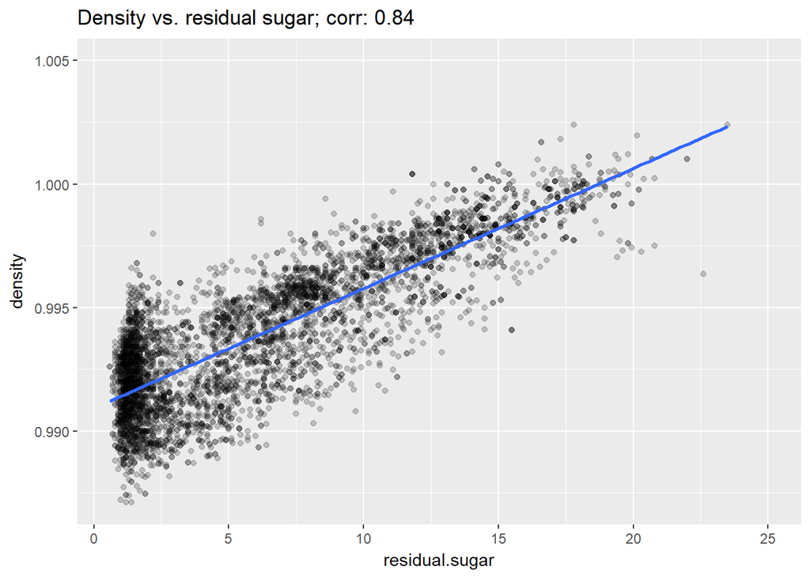

The correlation value between density and residual sugar is highest at 0.84. This is evident from the scatter plot and it will be interesting to see how quality varies with these parameters.

### Plot of free sulfur dioxide vs. total sulfur dioxide

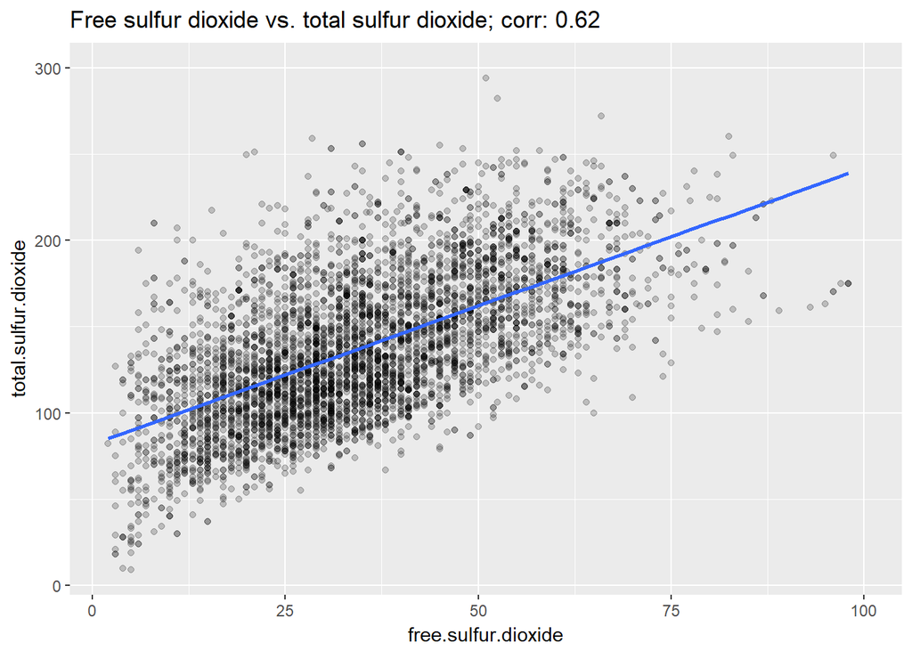

This pair was analyzed because of the high correlation value. However, considering that the free sulfur dioxide is a subset of the total sulfur dioxide according to the dataset, this comes as no surprise and this relationship will not be assessed with respect to quality.

# Bivariate Analysis

### Talk about some of the relationships you observed in this part of the investigation. How did the feature(s) of interest vary with other features in the dataset?

In summary, quality was found to be most closely correlated with alcohol and density. However, even these relations were not very strong and inconsistencies in some wine quality categories with less number of representative wines were observed.

### Did you observe any interesting relationships between the other features (not the main feature(s) of interest)?

The correlation between alcohol and density and residual sugar and density was found to be highest at 0.8. This was followed by a correlation of 0.6 between free sulfur dioxide and total sulfur dioxide. The last is evident because of the subset-superset nature of the variables.

### What was the strongest relationship you found?

The strongest relationship was that between density and residual sugar. These factors are positively correlated with a factor of 0.84.

# Multivariate Plots Section

From the previous section it was found that the relationship among quality, density, alcohol, and residual sugar are good candidates for further investigation.

### Plot of density vs. alcohol by quality

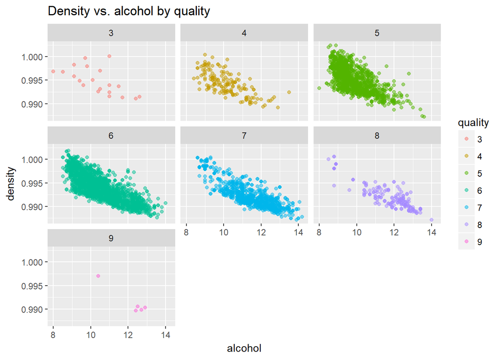

As seen previously, there is a negative correlation between the density and alcohol levels. When segregated by quality, it is observed that while low and mediocre quality wines have values across the entire range, high quality wines typically have high alcohol content and minimum values of density.

### Plot of density vs. residual sugar by quality

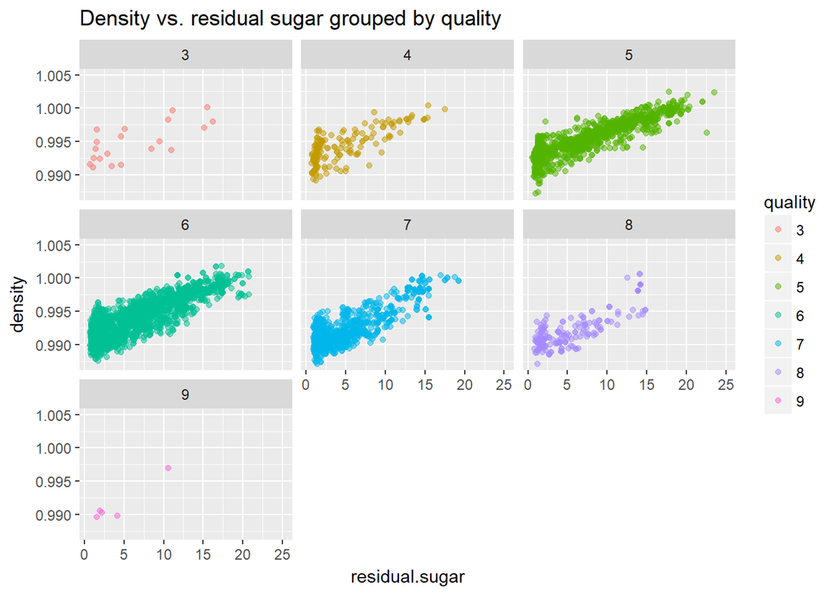

The positive correlation between the density and residual sugar is maintained across wines of all qualities. Furthermore, it is observed that high quality wines tend to have low values of density as well as residual sugar.

### Plot of alcohol vs. residual sugar by quality

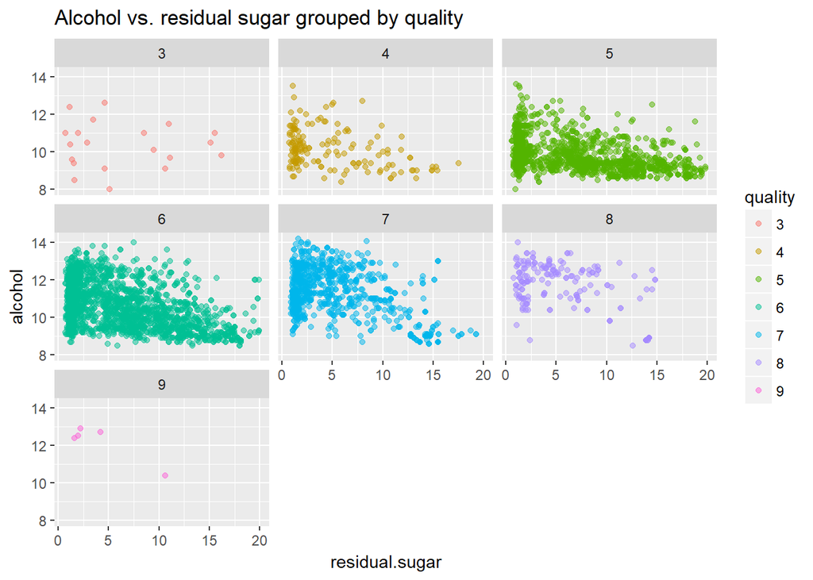

This plot confirms the findings of the previous plots, namely, wines of high quality have high alcohol content and low residual sugar.

### Linear regression model

Density, residual sugar, and alcohol parameters were used to construct a linear regression model for determining the quality of wines.

```
##
## Call:
## lm(formula = I(as.numeric(quality)) ~ I(alcohol) + I(1/density) +
##     I(1/residual.sugar), data = wineData)
##
## Residuals:
##     Min      1Q  Median      3Q     Max
## -3.6208 -0.5419  0.0094  0.4809  3.1089
##
## Coefficients:
##                      Estimate Std. Error t value Pr(>|t|)
## (Intercept)         -20.49455    7.94914  -2.578  0.00996 **
## I(alcohol)            0.30330    0.01619  18.729  < 2e-16 ***
## I(1/density)         21.21014    8.04957   2.635  0.00844 **
## I(1/residual.sugar)  -0.45213    0.05283  -8.558  < 2e-16 ***
## ---
## Signif. codes:  0 '***' 0.001 '**' 0.01 '*' 0.05 '.' 0.1 ' ' 1
##
## Residual standard error: 0.7902 on 4894 degrees of freedom
## Multiple R-squared:  0.2044, Adjusted R-squared:  0.2039
## F-statistic:   419 on 3 and 4894 DF,  p-value: < 2.2e-16
```

# Multivariate Analysis

### Talk about some of the relationships you observed in this part of the investigation. Were there features that strengthened each other in terms of looking at your feature(s) of interest?

Plotting the various combinations of density, residual sugar, and alcohol by quality brought out features of high quality wines, specifically, high alcohol content, low residual sugar, and low density.

### Were there any interesting or surprising interactions between features?

The findings in this section reinforced the correlation between alcohol and density and residual sugar and density across all wine qualities.

### Did you create any models with your dataset? Discuss the strengths and limitations of your model.

Yes, I created a linear regression model using the abovementioned variables. Unfortunately, these parameters proved to be inadequate to predict the variance in quality, the R-squared was only about 20%. It could be that the imbalance in data induced errors in analysis.

# Final Plots and Summary

### Plot One

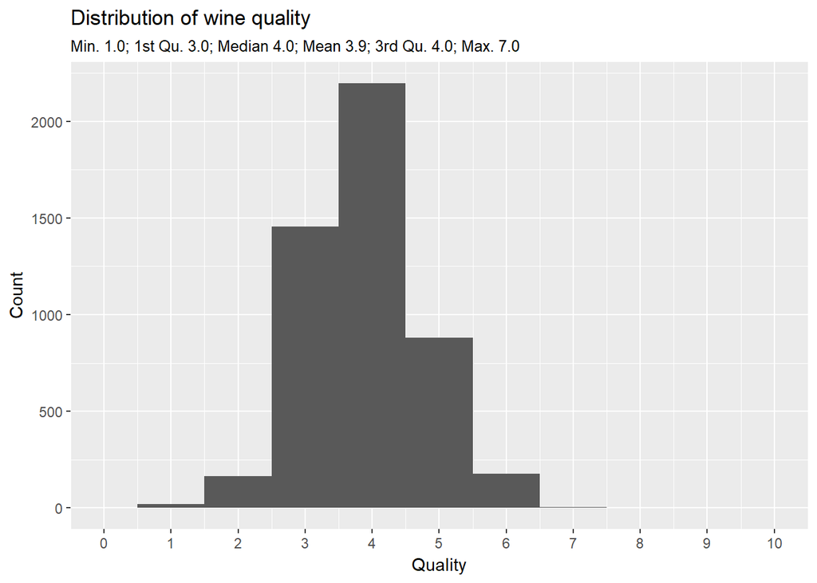